# FIGARO dosereport

Tue Dec 5 15:07:48 2017

When you use this report or results from this report in your work, please credit:

E.L. Hansen, O.C. Lind, D.H. Oughton, B. Salbu. A framework for exposure characterization and gamma dosimetry at the NMBU FIGARO irradiation facility. International Journal of Radiation Biology, DoReMi special issue (2017, submitted).

To access the full dosimetry framework, please visit: https://github.com/lindbohansen/FIGARO

# NKS cosms

This project investigates the response of whole miniature freshwater ecoystems to four levels of dose at FIGARO.

Exposures started 2016-10-11 18:41:00 and ended 2016-11-01 08:32:00.

### Participants

The following people participated in this project:

| name | role | email | telephone |
| --- | --- | --- | --- |
| Tanya Helena Hevrøy | project leader | tanya.hevroy@nrpa.no | 0047 000 00 000 |
| Clare Bradshaw | project participant | clare.bradshaw@su.se | 0000 000 00 000 |
| … | … | … | … |
| Elisabeth Lindbo Hansen | dosimetry consultant | elisabeth.hansen@nrpa.no | 0047 416 47 353 |

### Types of setups

The project used the following types of setups, where xcm refers to the width of the setup in the direction going outwards from the door; ycm refers to the height of the setup in the direction going upwards from the floor; and zcm refers to the depth of the setup along the central field axis going outwards from the source towards the back wall:

| type | xcm | ycm | zcm | approximateshape | actualshape | materials |
| --- | --- | --- | --- | --- | --- | --- |
| cosms | 20 | 20 | 10 | box | box | water-plexiglass |

### Positions

Setups were placed at the following positions in the field (see figure below), where Xcm refers to the distance from the central field axis to the midpoint of the setup in the direction going outwards from the door; Ycm refers to the distance from the floor to the lowest point of the setup in the direction going upwards from the floor; and Zcm refers to the distance from the source focus to the front face of the setup in the direction going outwards from the source towards the backwall (this distance equals the distance from the exit face of the collimator to the setup front face plus 41.7 cm).

SSDL-defined field axis air kerma rates list the mean of air kerma rates free in air on the SSDL-defined field axis at the specified distances of Zcm to the source focus on the exposure start (2016-10-11 18:41:00) and end (2016-11-01 08:32:00) dates. Note that these are mean air kerma rates on the SSDL-defined field axis. Setups that are placed closer to the central field axis may receive slightly higher mean air kerma rates. Setups that are placed farther away from the central field axis than the SSDL-defined field axis, will generally receive lower mean air kerma rates.

| type | position | Xcm | Ycm | Zcm | ssdlAxisAirKermaRatemGyperh |
| --- | --- | --- | --- | --- | --- |
| cosms | 1B | -10.60 | 65.0 | 196.2 | 22.1 |
| cosms | 1T | -10.60 | 87.6 | 196.2 | 22.1 |
| cosms | 2L | 10.60 | 65.0 | 315.7 | 8.46 |
| cosms | 2R | 32.05 | 65.0 | 315.7 | 8.46 |
| cosms | 3L | 10.60 | 90.9 | 640.7 | 2.03 |
| cosms | 3LC | 32.05 | 90.9 | 640.7 | 2.03 |
| cosms | 3R | 74.95 | 90.9 | 640.7 | 2.03 |
| cosms | 3RC | 53.50 | 90.9 | 640.7 | 2.03 |
| cosms | 4BC | 32.05 | 134.0 | 1015.7 | 0.800 |
| cosms | 4BL | 10.60 | 134.0 | 1015.7 | 0.800 |
| cosms | 4BR | 53.50 | 134.0 | 1015.7 | 0.800 |
| cosms | 4TC | 32.05 | 156.6 | 1015.7 | 0.800 |
| cosms | 4TL | 10.60 | 156.6 | 1015.7 | 0.800 |
| cosms | 4TR | 53.50 | 156.6 | 1015.7 | 0.800 |

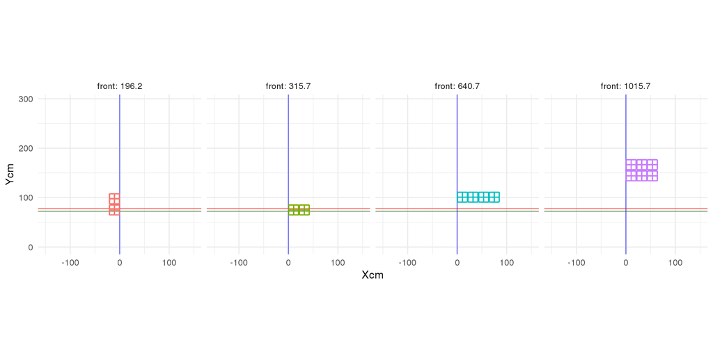

Fig: Positions of setups in the field. The intersection between the vertical blue and horizonthal green lines shows the location of the central field axis. The intersection between the vertical blue and horizonthal red lines show the location of the SSDL-defined field axis.

### Rotations and exposure times

There were a total of 4 rotations in this experiment. A rotation comprises the set of successive exposure times for which the whole setup remains exactly the same over the full exposure room.

| rotation | rotationstart | rotationstop | rotationtime |
| --- | --- | --- | --- |
| 10.10. | 2016-10-11 16:41:00 | 2016-10-13 14:14:00 | 2545 mins |
| 13.10. | 2016-10-13 17:52:00 | 2016-10-20 14:02:00 | 9542 mins |
| 20.10. | 2016-10-20 17:45:00 | 2016-10-27 13:52:00 | 9514 mins |
| 27.10. | 2016-10-27 17:36:00 | 2016-11-01 07:32:00 | 6370 mins |

### Minimum, maximum and average absorbed dose rates and accumulated absorbed doses

Setups received the following accumulated absorbed doses (accumulated_Gy), at the following average (avg_mGyperh), minimum (min_mGyperh) and maximum (max_mGyperh) absorbed dose rates. The relative standard uncertainty on the absorbed dose rates is estimated to 8%.

| id | accumulated_Gy | absorbedDoseRateToWhat | avg_mGyperh | min_mGyperh | max_mGyperh |
| --- | --- | --- | --- | --- | --- |
| 19 | 8.8 | water for the whole-setup | 19. | 17. | 20. |
| 2 | 8.6 | water for the whole-setup | 18. | 17. | 20. |
| 4 | 3.7 | water for the whole-setup | 7.9 | 7.6 | 8.1 |
| 9 | 3.6 | water for the whole-setup | 7.8 | 7.6 | 8.1 |
| 13 | 0.81 | water for the whole-setup | 1.7 | 1.5 | 1.8 |
| 22 | 0.80 | water for the whole-setup | 1.7 | 1.5 | 1.8 |
| 14 | 0.78 | water for the whole-setup | 1.7 | 1.5 | 1.8 |
| 5 | 0.78 | water for the whole-setup | 1.7 | 1.5 | 1.8 |
| 11 | 0.34 | water for the whole-setup | 0.73 | 0.72 | 0.74 |
| 15 | 0.34 | water for the whole-setup | 0.73 | 0.72 | 0.75 |
| 18or8_b | 0.34 | water for the whole-setup | 0.73 | 0.72 | 0.74 |
| 6 | 0.34 | water for the whole-setup | 0.72 | 0.70 | 0.74 |
| 18or8_a | 0.33 | water for the whole-setup | 0.72 | 0.69 | 0.73 |
| 20 | 0.33 | water for the whole-setup | 0.72 | 0.69 | 0.75 |

You can report information from this table in your work e.g. as:

Setup 19 received an accumulated absorbed dose to water for the whole-setup of 8.8 Gy over a net exposure time of 466 hours at an average beam-on absorbed dose rate of 19. mGy/h (range from 17. mGy/h to 20. mGy/h).

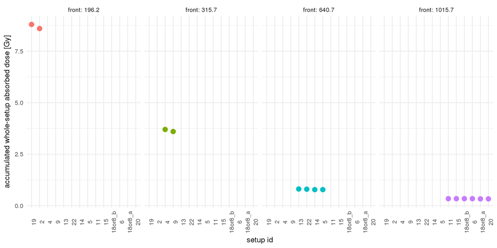

Fig: Accumulated absorbed doses per setup.

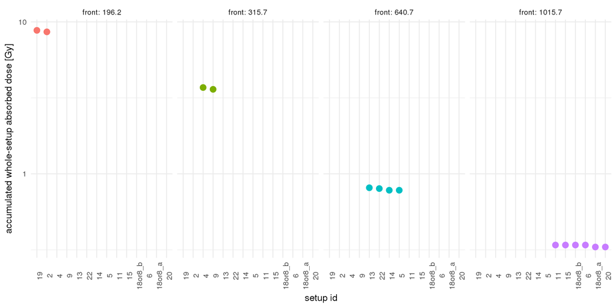

Fig: Accumulated absorbed doses per setup with a logarithmic y-axis.

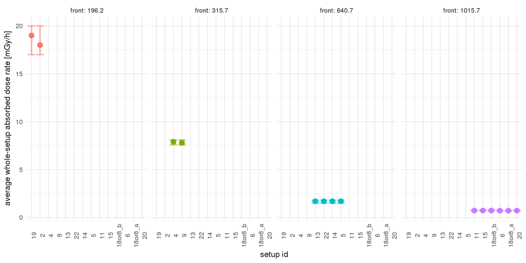

Fig: Average, minimum and maximum absorbed dose rates per setup.

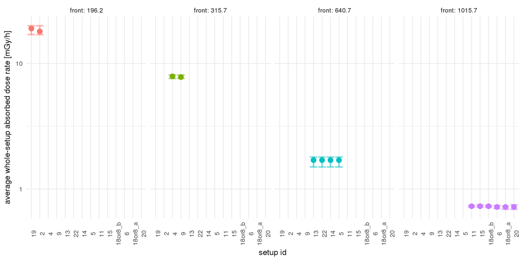

Fig: Average, minimum and maximum absorbed dose rates per setup with a logarithmic y-axis.

### Appendix (WIP): Raw dose rates and total doses per position and rotation

| id | type | rotation | position | absorbedDoseRatemGyperh | absorbedDoseGy |
| --- | --- | --- | --- | --- | --- |
| 11 | cosms | 10.10. | 4TC | 0.7376837 | 0.0312901 |
| 11 | cosms | 13.10. | 4TR | 0.7163968 | 0.1139310 |
| 11 | cosms | 20.10. | 4BR | 0.7282954 | 0.1154834 |
| 11 | cosms | 27.10. | 4BC | 0.7426673 | 0.0788465 |
| 13 | cosms | 10.10. | 3R | 1.4984292 | 0.0635584 |
| 13 | cosms | 13.10. | 3L | 1.7517413 | 0.2785853 |
| 13 | cosms | 20.10. | 3LC | 1.7778685 | 0.2819107 |
| 13 | cosms | 27.10. | 3RC | 1.7705792 | 0.1879765 |
| 14 | cosms | 10.10. | 3RC | 1.7816925 | 0.0755735 |
| 14 | cosms | 13.10. | 3R | 1.4959934 | 0.2379128 |
| 14 | cosms | 20.10. | 3L | 1.7473357 | 0.2770692 |
| 14 | cosms | 27.10. | 3LC | 1.7741176 | 0.1883521 |
| 15 | cosms | 10.10. | 4BR | 0.7313204 | 0.0310202 |
| 15 | cosms | 13.10. | 4BC | 0.7461139 | 0.1186570 |
| 15 | cosms | 20.10. | 4BL | 0.7234208 | 0.1147104 |
| 15 | cosms | 27.10. | 4TC | 0.7330824 | 0.0778289 |
| 18or8_a | cosms | 10.10. | 4BL | 0.7264256 | 0.0308126 |
| 18or8_a | cosms | 13.10. | 4TL | 0.6949293 | 0.1105169 |
| 18or8_a | cosms | 20.10. | 4TC | 0.7346324 | 0.1164882 |
| 18or8_a | cosms | 27.10. | 4TR | 0.7130875 | 0.0757061 |
| 18or8_b | cosms | 10.10. | 4TR | 0.7175633 | 0.0304366 |
| 18or8_b | cosms | 13.10. | 4BR | 0.7301316 | 0.1161153 |
| 18or8_b | cosms | 20.10. | 4BC | 0.7442375 | 0.1180113 |
| 18or8_b | cosms | 27.10. | 4BL | 0.7218945 | 0.0766411 |
| 19 | cosms | 10.10. | 1T | 17.0699149 | 0.7240489 |
| 19 | cosms | 13.10. | 1B | 20.3619407 | 3.2382273 |
| 19 | cosms | 20.10. | 1T | 16.9993065 | 2.6955234 |
| 19 | cosms | 27.10. | 1B | 20.2678794 | 2.1517732 |
| 2 | cosms | 10.10. | 1B | 20.3950935 | 0.8650919 |
| 2 | cosms | 13.10. | 1T | 17.0421672 | 2.7102727 |
| 2 | cosms | 20.10. | 1B | 20.3107308 | 3.2206049 |
| 2 | cosms | 27.10. | 1T | 16.9634415 | 1.8009520 |
| 20 | cosms | 10.10. | 4BC | 0.7473287 | 0.0316992 |
| 20 | cosms | 13.10. | 4BL | 0.7252447 | 0.1153381 |
| 20 | cosms | 20.10. | 4TL | 0.6931816 | 0.1099155 |
| 20 | cosms | 27.10. | 4TC | 0.7330824 | 0.0778289 |
| 22 | cosms | 10.10. | 3L | 1.7545934 | 0.0744240 |
| 22 | cosms | 13.10. | 3LC | 1.7823511 | 0.2834532 |
| 22 | cosms | 20.10. | 3RC | 1.7743227 | 0.2813484 |
| 22 | cosms | 27.10. | 3R | 1.4890827 | 0.1580909 |
| 4 | cosms | 10.10. | 2R | 7.6040426 | 0.3225381 |
| 4 | cosms | 13.10. | 2L | 8.1202771 | 1.2913947 |
| 4 | cosms | 20.10. | 2R | 7.5725891 | 1.2007602 |
| 4 | cosms | 27.10. | 2L | 8.0827657 | 0.8581203 |
| 5 | cosms | 10.10. | 3LC | 1.7852531 | 0.0757245 |
| 5 | cosms | 13.10. | 3RC | 1.7787963 | 0.2828879 |
| 5 | cosms | 20.10. | 3R | 1.4922310 | 0.2366181 |
| 5 | cosms | 27.10. | 3L | 1.7436492 | 0.1851174 |
| 6 | cosms | 10.10. | 4TL | 0.6960608 | 0.0295246 |
| 6 | cosms | 13.10. | 4TC | 0.7364846 | 0.1171256 |
| 6 | cosms | 20.10. | 4TR | 0.7145951 | 0.1133110 |
| 6 | cosms | 27.10. | 4BR | 0.7267588 | 0.0771576 |
| 9 | cosms | 10.10. | 2L | 8.1334983 | 0.3449959 |
| 9 | cosms | 13.10. | 2R | 7.5916820 | 1.2073305 |
| 9 | cosms | 20.10. | 2L | 8.0998547 | 1.2843670 |
| 9 | cosms | 27.10. | 2R | 7.5566125 | 0.8022604 |

### Appendix (WIP): Measured doses and validation of simulated doses